# My R Markdown Primer

Anuli Segree

2026-04-11

# Introduction

R Markdown is a file format that allows me to combine regular writing, R code, and mathematical notation in a single document. It is useful because I can explain my ideas in words, run code in the same file, and then knit everything into a clean final report. This makes it easier to keep my analysis organized and reproducible.

# Narrative Text

One thing I like about R Markdown is that it blends explanation and analysis together. Instead of writing code in one place and results somewhere else, I can keep everything in the same document. This helps make my work easier to follow because the text explains what the code is doing, and the output appears directly underneath it.

# LaTeX Math

Here is an example of inline math: $\alpha + \beta = \gamma$

Here is a displayed equation:

$$\bar{x} = \frac{1}{n}\sum_{i=1}^{n} x_i$$

This equation shows the formula for the sample mean.

# Code Chunk 1: Load a Dataset and View Summary

```r
library(ggplot2)
data(mtcars)
summary(mtcars)
```

```
##       mpg             cyl             disp             hp
##  Min.   :10.40   Min.   :4.000   Min.   : 71.1   Min.   : 52.0
##  1st Qu.:15.43   1st Qu.:4.000   1st Qu.:120.8   1st Qu.: 96.5
##  Median :19.20   Median :6.000   Median :196.3   Median :123.0
##  Mean   :20.09   Mean   :6.188   Mean   :230.7   Mean   :146.7
##  3rd Qu.:22.80   3rd Qu.:8.000   3rd Qu.:326.0   3rd Qu.:180.0
##  Max.   :33.90   Max.   :8.000   Max.   :472.0   Max.   :335.0
##       drat             wt             qsec             vs
##  Min.   :2.760   Min.   :1.513   Min.   :14.50   Min.   :0.0000
##  1st Qu.:3.080   1st Qu.:2.581   1st Qu.:16.89   1st Qu.:0.0000
##  Median :3.695   Median :3.325   Median :17.71   Median :0.0000
##  Mean   :3.597   Mean   :3.217   Mean   :17.85   Mean   :0.4375
##  3rd Qu.:3.920   3rd Qu.:3.610   3rd Qu.:18.90   3rd Qu.:1.0000
##  Max.   :4.930   Max.   :5.424   Max.   :22.90   Max.   :1.0000
##        am              gear            carb
##  Min.   :0.0000   Min.   :3.000   Min.   :1.000
##  1st Qu.:0.0000   1st Qu.:3.000   1st Qu.:2.000
##  Median :0.0000   Median :4.000   Median :2.000
##  Mean   :0.4062   Mean   :3.688   Mean   :2.812
##  3rd Qu.:1.0000   3rd Qu.:4.000   3rd Qu.:4.000
##  Max.   :1.0000   Max.   :5.000   Max.   :8.000
```

# Code Chunk 2: Create a Plot

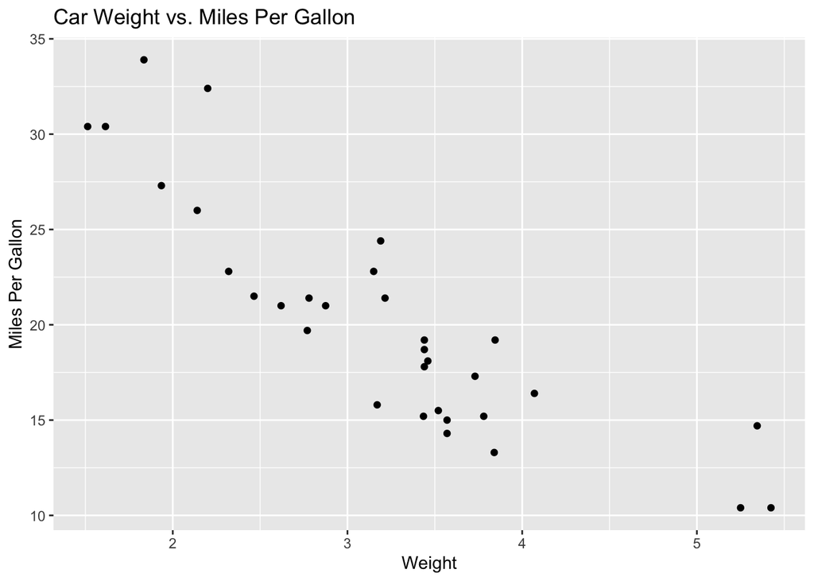

```r
ggplot(mtcars, aes(x = wt, y = mpg)) +
  geom_point() +
  labs(
    title = "Car Weight vs. Miles Per Gallon",
    x = "Weight",
    y = "Miles Per Gallon"
  )
```

# Reflection

Using R Markdown felt more efficient than writing a plain report because I could include my explanation, code, and results in one file. I also liked that the final knitted document looked cleaner and more professional. One challenge was remembering the correct Markdown and code chunk syntax, but once I saw how it worked, it became much easier to use.